# backpropagation

```python
import pandas as pd
import numpy as np
import matplotlib.pyplot as plt
%matplotlib inline
import seaborn as sns
sns.set(context="paper" , style ="whitegrid",rc={"figure.facecolor":"white"})

from numpy.random import *
```

## Multiple Perceptron

```python
class Net():
    def activation(self,x):
        return(1/(1+np.exp(-x)))

    def propa(self,xx = None):
        if  xx :
            self.l[0] = xx
        for i in range(self.n_layer -1 ):
            u = self.w[i].dot(np.r_[self.l[i],np.array([1])])
            self.l[i+1] = self.activation(u)

    def create(self,n_in_e = [3,2,2,5]):
        self.n_in_e = n_in_e
        self.n_layer = len(n_in_e)
        self.l = [[0 for i in range(n_in_e[j])] for j in range(self.n_layer)  ]
        self.w = [rand(n_in_e[i+1],n_in_e[i]+1)*2 -1  for i in range(self.n_layer-1)]
        self.propa()

    def structure(self):
        print("# of layers :",len(self.l))
        print("# of each neurons for each layer :",[len(self.l[i]) for i in range(len(self.l))])
        print("----------weights----------")
        print(self.w)
        print("----------state of neurons----------")
        print(self.l)
```

```python
N1 = Net()
print(N1.create([3,2,2,5]))
print("-------checking part-------------")
N1.structure()
```

```
None
-------checking part-------------
# of layers : 4
# of each neurons for each layer : [3, 2, 2, 5]
----------weights----------
[array([[-0.45040974,  0.20210378,  0.87702839,  0.41459262],
       [-0.47319367, -0.75532816, -0.08255154,  0.949625  ]]), array([[ 0.36114875, -0.61349254, -0.90652155],
       [ 0.90528787,  0.71729803,  0.65580635]]), array([[ 0.92780105,  0.1978729 ,  0.86183167],
       [-0.70646237, -0.77207938, -0.2559422 ],
       [ 0.53312025, -0.35771594,  0.27607016],
       [-0.9815578 ,  0.08693008, -0.32449071],
       [ 0.79604862,  0.88141408, -0.2317563 ]])]
----------state of neurons----------
[[0, 0, 0], array([0.60218859, 0.72103976]), array([0.24390386, 0.84789178]), array([0.77831963, 0.25295934, 0.52567636, 0.37984901, 0.67034521])]
```

# Perceptron

## data

```python
x = [[0,0],[0,1],[1,0],[1,1]]
y = [[0],[1],[1],[0]]
```

```python
for i ,j in zip(x,y):
    print(i,j)
```

```
[0, 0] [0]
[0, 1] [1]
[1, 0] [1]
[1, 1] [0]
```

## learning section

```python
class Net_learn(Net):
    nThin = 1000
    def update(self,eta,n_epoch,x,y):
        self.er_rec = []
        for i in range(n_epoch):
            del_E = np.zeros(129)
            error = 0
            for xx, yy in zip(x,y):
                self.propa(xx)
                output = self.l[-1]
                z_hidden = np.r_[self.l[-2],np.array([1])]
                del_E = del_E - (yy - output)*output*(1 - output)*z_hidden
                if i % self.nThin == 0:
                    error = error + np.sum( (yy - output)**2 )
            self.w[1] = self.w[1] - eta*del_E
            if i%self.nThin == 0:
                self.er_rec.append([i,error])
                print(i,error,self.l[-1])
```

```python
Ptr = Net_learn()
Ptr.create([2,128,1])
np.random.seed(10)
for i in range(128):
    if rand(1)<0.5:
        Ptr.w[0][i,0] = 0
    if rand(1) < 0.5:
        Ptr.w[0][i,1] = 0
Ptr.structure()
```

[output not shown]

[output cut: 128 more lines]

[output not shown]

```python
Ptr.update(0.5,int(10000),x,y)
```

```
0 1.1953158480573192 [0.47352989]
1000 1.272591200179911 [0.35441749]
2000 1.2013683741520118 [0.33581989]
3000 1.128481610142497 [0.33876717]
4000 0.9488670742567731 [0.44830456]
5000 1.0634934611134124 [0.7914551]
6000 1.548474765559316 [0.9215379]
7000 1.6816808378263133 [0.94532027]
8000 0.45719202977654677 [0.21111745]
9000 1.4142029582720643 [0.88044601]
```

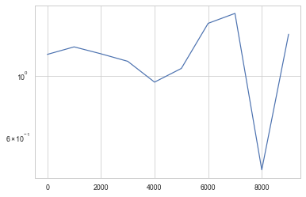

```python
rec = np.ravel(Ptr.er_rec).reshape((2,-1),order="F")
plt.yscale("log")
plt.plot(rec[0],rec[1])
```

# Multiple Perceptron and Backpropagation

## Back propagation theory

### notation

$ z_{i}^{(l)n} $ : neuron state in i th of l layers. and this state is n th batch.  
________$ z_{i}^{(l)n} $ is corresponding to z[ l ][ i ]  
$ w_{ij}^{(l)} $ : weights from j to i in l layers. l means between $z^{l}$ and $ z^{l + 1}$  
________$ w_{ij}^{(l)} $ : is corresponding to w[ l ][ i , j ]  
$ E_n $ : is error function for batch n, so $ E $ is written as \begin{equation} E = \sum_n E_n = \sum_n \sum_i \frac{1}{2}( z_i^{Tn} - z_i^{On} )^2 \end{equation} where $ z_i^{Tn} $ is i th teacher data of n th batch  
$ z_i^{On} $ is i th output data of n th batch

### theory

the basic relationship between z and w is

\begin{equation} z_{i}^{(l+1)n} = f(\sum_j w_{ij}^{(l)}z_{j}^{(l)n}) \end{equation}

we frequently use this relationship to calculate each renewal equations.

the equation for parameteres updates is written as

\begin{align} w_{ij}^{(l-1)}(t+1) &= w_{ij}^{(l-1)}(t) - \eta\sum_{n}\frac{\partial E_n}{\partial w_{ij}^{(l-1)}} \\ &= w_{ij}^{(l-1)}(t) - \eta\sum_{n}\frac{\partial E_n}{\partial z_{i}^{(l)n}} \frac{\partial z_{i}^{(l)n}}{ w_{ij}^{(l-1)}} \end{align}

For the output data \begin{equation} \frac{\partial E_n}{\partial z_{i}^{(l)n}} = - ( z_{i}^{Tn} - z_{i}^{On}) \\ \frac{\partial z_{i}^{(l)n}}{w_{ij}^{(l-1)}} = z_{i}^{(l)n}(1 - z_{i}^{(l)n}) z_{j}^{(l-1)n} \end{equation} This equation below has assumption that activation func. is sigmoid func.

For the hidden layers, $ \frac{\partial z_{i}^{(l)n}}{w_{ij}^{(l-1)}} $ is same.  
But derivative of $E_n$ is different. This part is essential for back propagation.

The parameter $z_{i}^{(l)n} $ affects all of $ z_{k}^{(l + 1)n} $, so that

\begin{align} \frac{\partial E_n}{\partial z_{i}^{(l)n}} &= \sum_k \frac{\partial E_n}{\partial z_{k}^{(l+1 )n}}\frac{\partial z_{k}^{(l+1)n}}{\partial z_{i}^{(l)n}} \\ &= \sum_k \frac{\partial E_n}{\partial z_{k}^{(l+1 )n}}z_k^{(l+1)}(1- z_k^{(l+1)n})w_{ki}^{(l)} \end{align}

### For implementation

we have to prepare

1. Network ( # of layers, # of neurons for each layers )
2. store derivative values for neurons for each batch ( lack first input of network structure )
3. store derivative values for weights for each epoch

### Algorithm

for n_epoch  
|___for n_batch  
|______1. propagation  
|______2. back propagation  
|______3. store derivative values  
|___4. parameter update

[figure not shown]

```python
class backpropagation(Net):
    def get_l_ptl(self,yy):
        self.l_ptl = [0 for i in self.n_in_e[1:]]
        self.l_ptl[-1] = -(yy - self.l[-1])
        for i in range(1,self.n_layer -1 ):
            self.l_ptl[-(i+1)] = self.w[-i][:,:-1].T.dot(self.l_ptl[-i]*self.l[-i]*(1-self.l[-i]))

    def get_w_ptl(self):
        w_ptl_n = [np.zeros((self.n_in_e[i+1],self.n_in_e[i] + 1)) for i in range(self.n_layer-1)]
        for l_1 in range(self.n_layer-1):
            del_i,del_j = np.meshgrid(np.r_[self.l[l_1],np.array([1]) ]
                    ,self.l_ptl[l_1]*self.l[l_1 + 1]*(1-self.l[l_1 + 1]))

            w_ptl_n[l_1] = del_i*del_j
        return(w_ptl_n)

    def bk_propa(self,eta,n_epoch,x,y):
        # l_ptl index i is i + 1 in network

        self.er_rec = []
        for epoch in range(n_epoch):
            self.w_ptl = [np.zeros((self.n_in_e[i+1],self.n_in_e[i]+1)) for i in range(self.n_layer-1)]
            error = 0
            for  xx,yy in zip(x,y):
                self.propa(xx)
                self.get_l_ptl(yy)
                w_ptl_n = self.get_w_ptl()
                for i in range(self.n_layer -1):
                    self.w_ptl[i] = self.w_ptl[i] + w_ptl_n[i]
                if epoch % 500 == 0:
#                     print(self.l[-1])
                    error = error + np.sum( (yy - self.l[-1])**2 )
            for i in range(self.n_layer-1):
                self.w[i] = self.w[i] -eta*self.w_ptl[i]
            if epoch % 500 == 0:
                self.er_rec.append([epoch,error])
                print(epoch, error )

    def propa_data(self,data):
        self.l[0] = data
        for i in range(self.n_layer -1 ):
            u = self.w[i].dot(np.r_[self.l[i],np.array([1])])
            self.l[i+1] = self.activation(u)
```

```python
Ptr_b = backpropagation()
Ptr_b.create([2,2,1])
Ptr_b.structure()
```

```
# of layers : 3
# of each neurons for each layer : [2, 2, 1]
----------weights----------
[array([[-0.45040974,  0.20210378,  0.87702839],
       [ 0.41459262, -0.47319367, -0.75532816]]), array([[-0.08255154,  0.949625  ,  0.36114875]])]
----------state of neurons----------
[[0, 0], array([0.70620605, 0.31966143]), array([0.64712117])]
```

```python
Ptr_b.bk_propa(0.2,int(10000),x,y)
```

```
0 1.0845138332030162
500 0.9858475476781985
1000 0.89461110160475
1500 0.7621820754074731
2000 0.7140481105019613
2500 0.636141183991283
3000 0.15021422058266024
3500 0.049333508528988844
4000 0.02780523860502007
4500 0.019032818104318783
5000 0.014354089610969466
5500 0.011470100864482842
6000 0.009523994290716403
6500 0.0081267507051005
7000 0.007077223133958211
7500 0.006261311622994311
8000 0.005609633558414878
8500 0.005077648965982163
9000 0.004635495274310427
9500 0.004262423661968845
```

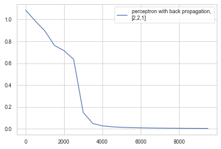

```python
rec1 = np.ravel(Ptr_b.er_rec).reshape((2,-1),order="F")
plt.plot(rec1[0],rec1[1],label="perceptron with back propagation, \n[2,2,1]")
plt.legend()
```

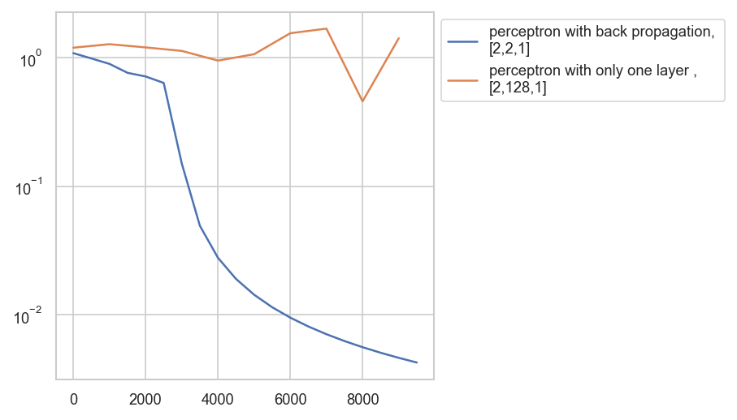

```python
rec1 = np.ravel(Ptr_b.er_rec).reshape((2,-1),order="F")

fig = plt.figure(figsize=(4,4),dpi=150)
ax = fig.add_subplot(1,1,1)
ax.set_yscale("log")
ax.plot(rec1[0],rec1[1],label="perceptron with back propagation, \n[2,2,1]")
ax.plot(rec[0],rec[1],label="perceptron with only one layer ,\n[2,128,1]")

#ax.set_xlabel(r"Description of $x$ coordinate (units)")
#ax.set_ylabel(r"Description of $y$ coordinate (units)")
#ax.set_title(r"Title here (remove for papers)")
#ax.set_xlim(np.min(x), np.max(x))
#ax.set_ylim(np.min(y),np.max(y))
ax.legend(bbox_to_anchor=(1, 1),loc="upper left")
```

```python
Ptr_b.w
```

```
[array([[-5.29604993,  4.99249987, -2.76780112],
        [ 6.3739615 , -6.26435392, -3.66136348]]),
 array([[ 8.28390048,  8.03501458, -4.02569435]])]
```

```python
Ptr_b.propa_data([0,0])
print(Ptr_b.l)
Ptr_b.propa_data([0,1])
print(Ptr_b.l)
Ptr_b.propa_data([1,0])
print(Ptr_b.l)
Ptr_b.propa_data([1,1])
print(Ptr_b.l)
```

```
[[0, 0], array([0.05908915, 0.02505364]), array([0.03439315])]
[[0, 1], array([9.02445645e-01, 4.88983797e-05]), array([0.96924511])]
[[1, 0], array([3.14613483e-04, 9.37765944e-01]), array([0.97102376])]
[[1, 1], array([0.04430458, 0.02787495]), array([0.03122831])]
```

[figure not shown]